# TidyTuesday Week 23 - Fast Food Calories

Roberto Preste

2018-09-04

```r
library(tidyverse)
library(stringr)
library(magrittr)
library(rvest)
library(funModeling)
library(skimr)
```

Original data come from fastfoodnutrition.org, and the original article about fast food calories comparison is available on [Franchise Opportunities](https://www.franchiseopportunities.com/blog/general-franchise-information/fast-food-calorie-comparison-charts).

Firstly, we need to scrape the data from the data source (function kindly provided by thomas_mock), then we can combine all the data and save them.

```r
food_scrape <- function(restaurant, tbl_sel){
    url <- glue::glue("https://fastfoodnutrition.org/{restaurant}/chart")
    url %>%
        read_html() %>%
        html_table() %>%
        .[tbl_sel] %>%
        bind_rows() %>%
        select(-X16) %>%
        set_names(nm = c("item", "calories", "cal_fat", "total_fat", "sat_fat", "trans_fat",
                         "cholesterol", "sodium", "total_carb", "fiber", "sugar", "protein",
                         "vit_a", "vit_c", "calcium")) %>%
        mutate(restaurant = str_replace(restaurant, "-", " "),
               restaurant = str_to_title(restaurant)) # save restaurant name
}
```

```r
mcd_df <- food_scrape("mcdonalds", c(1,2,3,9,19))
cfa_df <- food_scrape("chick-fil-a", c(1,2,8,13))
sonic_df <- food_scrape("sonic", c(1,2,17,18,20))
arbys_df <- food_scrape("arbys", c(1:4,8))
bk_df <- food_scrape("burger-king", c(1:3,7,11:12))
dq_df <- food_scrape("dairy-queen", c(5, 7, 12, 25, 27))
sub_df <- food_scrape("subway", c(1,2,3,4,5,6,7,8,9))
taco_df <- food_scrape("taco-bell", c(1,2,3,4,5,15,18,19,20,22,23,24))
final_df <- bind_rows(mcd_df, cfa_df, sonic_df, arbys_df, bk_df, dq_df, sub_df, taco_df) %>%
    select(restaurant, everything()) %>%
    mutate(salad = case_when(str_detect(item, "salad") ~ "Salad",
                             TRUE ~ "Other"))
final_df %>% write_csv("data/fastfood_calories.csv")
```

The final dataframe is available in `data/fastfood_calories.csv`.  
It contains nutritional information about entrees (main courses) from the specified fast foot franchises.

## Data exploration

Let’s have a quick view at the data.

```r
head(df)
```

| restaurant | item | calories | cal_fat | total_fat | sat_fat | trans_fat | cholesterol | sodium | total_carb | fiber | sugar | protein | vit_a | vit_c | calcium | salad |
| --- | --- | --- | --- | --- | --- | --- | --- | --- | --- | --- | --- | --- | --- | --- | --- | --- |
| Mcdonalds | Artisan Grilled Chicken Sandwich | 380 | 60 | 7 | 2 | 0.0 | 95 | 1110 | 44 | 3 | 11 | 37 | 4 | 20 | 20 | Other |
| Mcdonalds | Single Bacon Smokehouse Burger | 840 | 410 | 45 | 17 | 1.5 | 130 | 1580 | 62 | 2 | 18 | 46 | 6 | 20 | 20 | Other |
| Mcdonalds | Double Bacon Smokehouse Burger | 1130 | 600 | 67 | 27 | 3.0 | 220 | 1920 | 63 | 3 | 18 | 70 | 10 | 20 | 50 | Other |
| Mcdonalds | Grilled Bacon Smokehouse Chicken Sandwich | 750 | 280 | 31 | 10 | 0.5 | 155 | 1940 | 62 | 2 | 18 | 55 | 6 | 25 | 20 | Other |
| Mcdonalds | Crispy Bacon Smokehouse Chicken Sandwich | 920 | 410 | 45 | 12 | 0.5 | 120 | 1980 | 81 | 4 | 18 | 46 | 6 | 20 | 20 | Other |
| Mcdonalds | Big Mac | 540 | 250 | 28 | 10 | 1.0 | 80 | 950 | 46 | 3 | 9 | 25 | 10 | 2 | 15 | Other |

```r
skim(df)
```

```
Skim summary statistics
 n obs: 527
 n variables: 17

── Variable type:character ──────────────────────────────────────────────────────────────────────
   variable missing complete   n min max empty n_unique
       item       0      527 527   5  63     0      517
 restaurant       0      527 527   5  11     0        8
      salad       0      527 527   5   5     0        1

── Variable type:integer ────────────────────────────────────────────────────────────────────────
    variable missing complete   n    mean     sd p0   p25  p50     p75 p100     hist
     cal_fat       0      527 527  236.91 164.84  0 123    207  310    1270 ▆▇▃▁▁▁▁▁
     calcium     208      319 527   24.43  25.05  0   8     20   30     290 ▇▂▁▁▁▁▁▁
    calories       0      527 527  527.27 279.88 20 330    480  680    2430 ▅▇▃▁▁▁▁▁
 cholesterol       0      527 527   72.29  62.6   0  35     60   90     805 ▇▁▁▁▁▁▁▁
       fiber      16      511 527    4.17   3.02  0   2      3    5      17 ▇▇▃▂▂▁▁▁
     protein       1      526 527   27.92  17.53  1  16     25   35.75  186 ▇▇▁▁▁▁▁▁
      sodium       0      527 527 1233.47 684.46 15 795   1100 1540    6080 ▃▇▃▁▁▁▁▁
       sugar       0      527 527    7.33   6.71  0   3.5    6    9      87 ▇▂▁▁▁▁▁▁
  total_carb       0      527 527   45.27  24.68  0  28     44   56     156 ▃▆▇▃▂▁▁▁
   total_fat       0      527 527   26.38  18.24  0  14     23   34     141 ▆▇▃▁▁▁▁▁
       vit_a     224      303 527   20.32  36.07  0   4     10   20     250 ▇▁▁▁▁▁▁▁
       vit_c     208      319 527   22.08  31.57  0   4     10   40     400 ▇▁▁▁▁▁▁▁

── Variable type:numeric ────────────────────────────────────────────────────────────────────────
  variable missing complete   n mean   sd p0 p25 p50 p75 p100     hist
   sat_fat       0      527 527 8.02 6.36  0   4   7  10   47 ▇▇▂▁▁▁▁▁
 trans_fat       0      527 527 0.45 0.83  0   0   0   1    8 ▇▁▁▁▁▁▁▁
```

We can drop the `salad` feature, because it has the same value (`Other`) for all the observations in the data, so it’s uninformative.

```r
df %<>% select(-salad)
```

## Visualization

I chose to focus just on a couple of nutrients from these data, namely some of the most *feared* ones: fat and sugar.

### Fat content per franchise

Let’s visualize the general fat content of entrees per franchise, distinguished in total grams of fat, saturated fat and trans fat.

```r
fat_content <- df %>%
    group_by(restaurant) %>%
    summarise(Fat = mean(total_fat),
              Saturated = mean(sat_fat),
              Trans = mean(trans_fat)) %>%
    gather(measure, value, Fat:Trans)
```

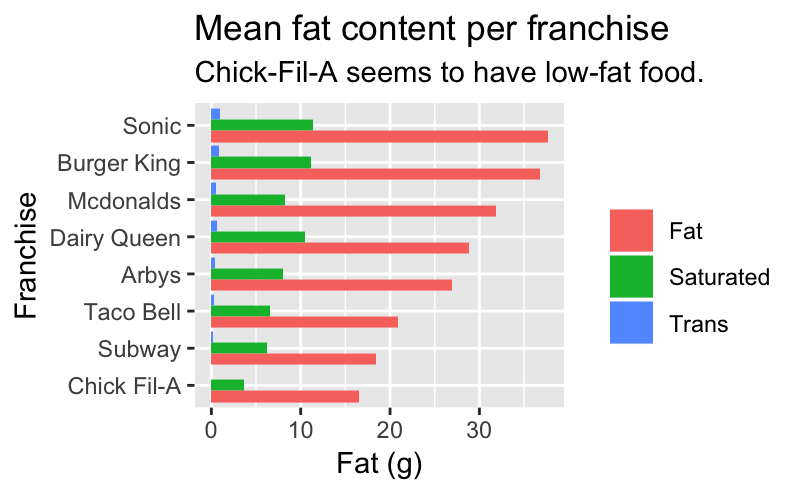

```r
fat_content %>%
    ggplot(aes(x = reorder(restaurant, value))) +
    geom_col(aes(y = value, fill = measure), position = "dodge") +
    coord_flip() +
    labs(x = "Franchise", y = "Fat (g)", title = "Mean fat content per franchise", fill = "", subtitle = "Chick-Fil-A seems to have low-fat food.")
```

Seems like, in general, Chick-Fil-A might offer food with a lower fat content, with Subway and Taco Bell immediately following. Choosing one of these three franchises can be two to three times an healthier options compared to other fast foods.

## Sugar content per franchise

Another bad player for our health is sugar, so let’s check how well our fast foods behave.

```r
sugar_content <- df %>%
    group_by(restaurant) %>%
    summarise(Sugar = mean(sugar))
```

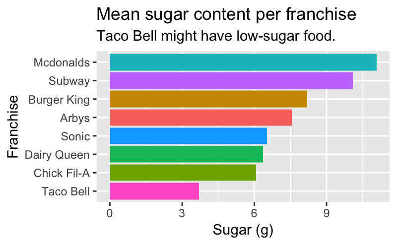

```r
sugar_content %>%
    ggplot(aes(x = reorder(restaurant, Sugar), y = Sugar, fill = restaurant)) +
    geom_col() +
    coord_flip() +
    labs(x = "Franchise", y = "Sugar (g)", title = "Mean sugar content per franchise", subtitle = "Taco Bell might have low-sugar food.") +
    guides(fill = FALSE)
```

A histogram can give a better overview of data and show possible outliers, represented by food with extremely high content of sugar.

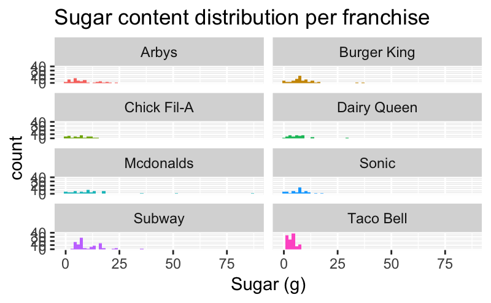

```r
df %>%
    ggplot(aes(x = sugar, fill = restaurant)) +
    geom_histogram(bins = 60) +
    facet_wrap(~ restaurant, nrow = 4, ncol = 2) +
    labs(x = "Sugar (g)", title = "Sugar content distribution per franchise") +
    guides(fill = FALSE)
```

Let’s zoom in a bit and remove the above-mentioned outliers.

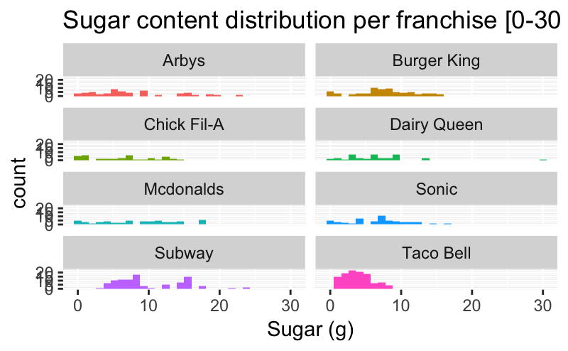

```r
df %>%
    filter(sugar <= 30) %>%
    ggplot(aes(x = sugar, fill = restaurant)) +
    geom_histogram(bins = 30) +
    facet_wrap(~ restaurant, nrow = 4, ncol = 2) +
    labs(x = "Sugar (g)", title = "Sugar content distribution per franchise [0-30 g]") +
    guides(fill = FALSE)
```

### Disclaimer

These are just some basic insights, created for simple data exploration and visualization purposes. I’m not a nutritionist, and these are not comprehensive data from which any useful and trustworthy information can be extracted.  
No conclusions should be drawn from what is reported here.